# Palmer Penguins Data Visualization

Dane Dela Cruz

2023-05-18

# Visualization in R

### Import libraries and load dataset

```r
library(palmerpenguins)
library(ggplot2)
data("penguins")
```

Below is an example exercise where I wrote a line of code to visualize an analysis based on the Palmer Penguins dataset collected by Dr. Kristen Gorman.

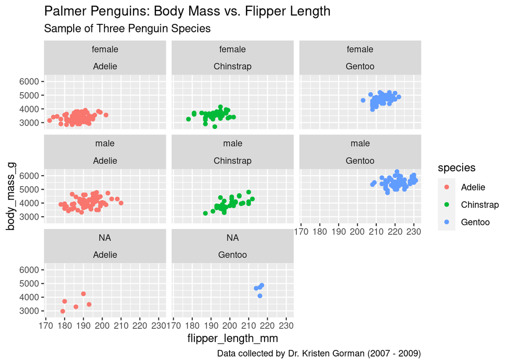

```r
ggplot(data = penguins) + geom_point(mapping = aes(x = flipper_length_mm, y = body_mass_g, color=species)) + facet_wrap(sex~species) + labs(title = "Palmer Penguins: Body Mass vs. Flipper Length", subtitle = "Sample of Three Penguin Species", caption = "Data collected by Dr. Kristen Gorman (2007 - 2009)")
```

## The Code

### Geom

To start building the code, I used the `geom()` function with the `point` variable to create a scatter plot.

### Aesthetic

An aesthetic is a visual property in the plot. The `mapping=aes` part of the code within the `geom_point()` function tells R what aesthetics to use for the plot. `aes` defines the mapping between the data and the plot. Within the `mapping=aes()` function, I defined the x and y axes as `x = flipper_length_mm, y = body_mass_g`, where the x axis measures the flipper length of the penguins, and the y axis measures the body mass of the penguins. Next, I defined the different species by color. For this, I used `color=species`, which concludes the mapping portion of the code.

### Adding additional layers

Moreover, I wanted to segment the species by sex by using the facet_wrap() function and indicating `sex~species` within the function. Lastly, I needed to add titles, subtitles, and lables to my plot. The final part of the code `labs(title = "Palmer Penguins: Body Mass vs. Flipper Length", subtitle = "Sample of Three Penguin Species", caption = "Data collected by Dr. Kristen Gorman (2007 - 2009)")` allowed me to do so.

And there it is! My first visualization in R!